# Training for BMKG - HYSPLIT

Centre for Research on Energy and Clean Air (CREA)

19 October 2020

# Backward trajectories using HYSPLIT

In this section, we will be using [HYSPLIT](https://www.ready.noaa.gov/HYSPLIT.php) to find out where the air reaching Jakarta is coming from. We’ll combine this with PM 2.5 levels to understand where potential transboundary sources of air pollution lie.

Note that this document is more of an introduction than an actual scientific analysis, as many potential factors and sensitivy analyses won’t be included.

## Installing packages

Beside more traditional packages, we weill be using three dedicated packages on air pollution, namely: - RCREA: CREA’s own package to retrieve air pollution levels - [Splitr](https://github.com/rich-iannone/splitr): a convenient wrapper for HYSPLIT calculation - [OpenAIR](https://davidcarslaw.github.io/openair/): a very powerful package to analyse air trajectories

```r
if(!require(rcrea)){devtools::install_github("energyandcleanair/rcrea"); require(rcrea)}
if(!require(splitr)){devtools::install_github("rich-iannone/splitr"); require(splitr)}
if(!require(openair)){devtools::install_github('davidcarslaw/openair'); library(openair)}
```

Other packages used for this tutorial are:

```r
library(lubridate)
library(pbmcapply)
library(dplyr)
library(ggmap)
library(ggplot2)
```

## Backward trajectories of a single date

Let’s take Jakarta and 1 September 2020 as an example.

HYSPLIT/Splitr needs some parameters: - weather dataset used to calculate trajectories - height of the ‘receptor’ - duration of the trajectories

```r
met_type <- "reanalysis" # or gdas1
height <- 10 #meter
duration <- 72 #hours
```

We also specify the folder where weather data will be cached (can take few GBs), and results temporarily stored.

```r
dir_hysplit_met <- "/Volumes/ext1/data/weather/hysplit_met/" # Folder where weather files will be downloaded/cached
dir_hysplit_output <- here::here("hysplit_output") # Folders where HYSPLIT results will be temporarily stored
```

Now we can run the backward trajectory calculations!

```r
trajs <- splitr::hysplit_trajectory(
      lon = lon,
      lat = lat,
      height = height,
      duration = duration,
      days = lubridate::date(date),
      daily_hours = c(0, 6, 12, 18), # The weather dataset is available every 6-hours
      direction = "backward",
      met_type = met_type,
      extended_met = F,
      met_dir = dir_hysplit_met,
      exec_dir = dir_hysplit_output,
      clean_up = F
)
trajs
```

```
## # A tibble: 292 x 12
##      run receptor hour_along traj_dt               lat   lon height
##    <int>    <int>      <int> <dttm>              <dbl> <dbl>  <dbl>
##  1     1        1          0 2020-09-01 00:00:00 -6.21  107.   10
##  2     1        1         -1 2020-08-31 23:00:00 -6.32  107.   11
##  3     1        1         -2 2020-08-31 22:00:00 -6.44  107.   11.9
##  4     1        1         -3 2020-08-31 21:00:00 -6.56  107.   12.7
##  5     1        1         -4 2020-08-31 20:00:00 -6.69  107.   13.4
##  6     1        1         -5 2020-08-31 19:00:00 -6.82  107.   13.9
##  7     1        1         -6 2020-08-31 18:00:00 -6.96  108.   14.3
##  8     1        1         -7 2020-08-31 17:00:00 -7.10  108.   14.7
##  9     1        1         -8 2020-08-31 16:00:00 -7.22  108.   15.2
## 10     1        1         -9 2020-08-31 15:00:00 -7.33  108.   15.8
## # … with 282 more rows, and 5 more variables: traj_dt_i <dttm>, lat_i <dbl>,
## #   lon_i <dbl>, height_i <dbl>, pressure <dbl>
```

The `trajs` dataframe contains the trajectories. Let’s plot them.

```r
plot_trajs <- function(trajs){

  # Get the boundary box: 50km around trajectories
  buffer_km <- 50
  bbox <- sf::st_as_sf(trajs, coords=c("lon","lat"), crs=4326) %>%
    sf::st_transform(crs=3857) %>% # Reproject in pseudo-mercator to have meter unit
    sf::st_buffer(buffer_km*1E3) %>%
    sf::st_transform(crs=4326) %>%
    sf::st_bbox() %>%
    unname()

  basemap <- ggmap::get_stamenmap(bbox = bbox,
                                  zoom = 8,
                                  where="/Volumes/ext1/data/basemap")

  ggmap(basemap) +
     coord_cartesian() +
      # trajectory lines
     geom_path(data = trajs %>%
                 dplyr::arrange(hour_along) %>%
                 mutate(subcluster=paste(traj_dt_i, hour_along %/% 8)),
               arrow = arrow(angle=18, length=unit(0.1,"inches")),
               aes(x = lon, y = lat, group=subcluster), color="darkred", alpha=0.6) +
      geom_path(data = trajs,
               aes(x = lon, y = lat, group=traj_dt_i), color="darkred", alpha=0.6) +
     # theme
     theme(panel.background = element_rect(fill='lightgray'),
           panel.border = element_rect(color='black', fill=NA),
           panel.grid = element_line(color=NA),
           plot.caption = element_text(lineheight = 0.9),
           legend.position="right",
           legend.key = element_rect(fill='white')) +
     labs(title=paste("Sources or air flowing into Jakarta"),
          subtitle = date,
          x='', y='',
          caption=paste0("Source: CREA based on HYSPLIT. ",
                         "Weather dataset: ", met_type, " ",
                         "Receptor height: ", height, "m. ",
                         "Duration: ", duration, " hour."))

}
```

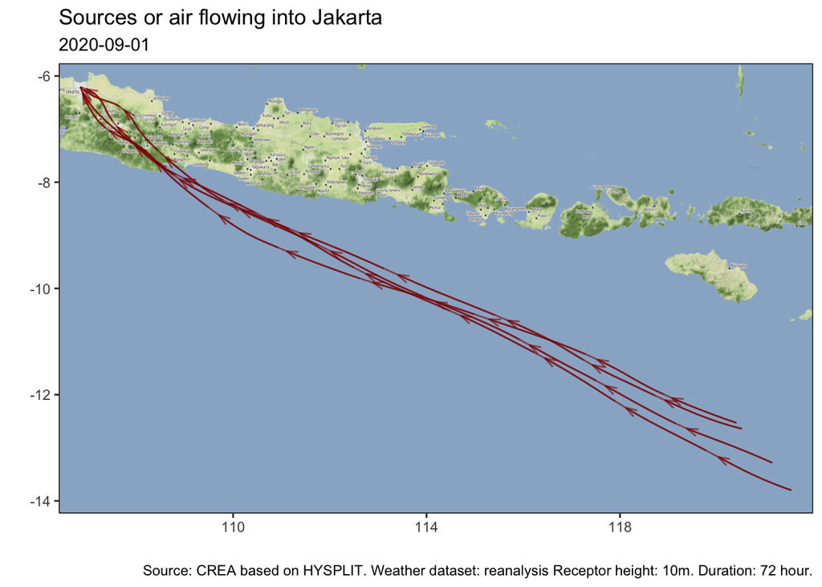

```r
plot_trajs(trajs)
```

# Trajectories over a longer period: 2019

We might be interested in trajectories over a longer period of time. Here we’ll consider the whole year of 2019.

```r
date_from <- "2019-01-01"
date_to <- "2019-12-31"
dates <- seq(lubridate::date(date_from), lubridate::date(date_to), by="d")
dates_split <- split(dates, ceiling(seq_along(dates)/5)) # Compute 5 days at time per core

trajs_at_dates <- function(dates){
  tryCatch({
    hysplit_trajectory(
      lon = lon,
      lat = lat,
      height = height,
      duration = duration,
      days = dates,
      daily_hours = c(0, 6, 12, 18),
      direction = "backward",
      met_type = met_type,
      extended_met = F,
      met_dir = dir_hysplit_met,
      exec_dir = dir_hysplit_output,
      clean_up = F
    )
  },
  error=function(c){
    return(NA)
  })
}

trajs.2019 <- do.call('rbind',
                 pbmclapply(dates_split, trajs_at_dates,
                            mc.cores = parallel::detectCores()-1))
```

We first need to make trajectories compatible with `openair` (e.g. rename or add certain fields):

```r
format_for_openair <- function(trajs){
   # Update fields to be compatible with OpenAIR
  trajs$hour.inc <- trajs$hour_along
  trajs$date <- trajs$traj_dt_i
  trajs$date2 <- trajs$traj_dt
  trajs$year <- lubridate::year(trajs$traj_dt_i)
  trajs$month <- lubridate::month(trajs$traj_dt_i)
  trajs$day <- lubridate::date(trajs$traj_dt_i)

  return(trajs)
}

trajs.2019 <- format_for_openair(trajs.2019)
```

Let’s also add PM2.5 values, using CREA R package.

```r
pm25.2019 <- rcrea::measurements(city="jakarta", source="openaq", date_from=date_from, date_to=date_to, poll=rcrea::PM25) %>%
  mutate(date=lubridate::date(date))
trajs.poll.2019 <- trajs.2019 %>% left_join(pm25.2019, by=c("day"="date"))
```

### Plotting monthly trajectories, colored by PM2.5 levels

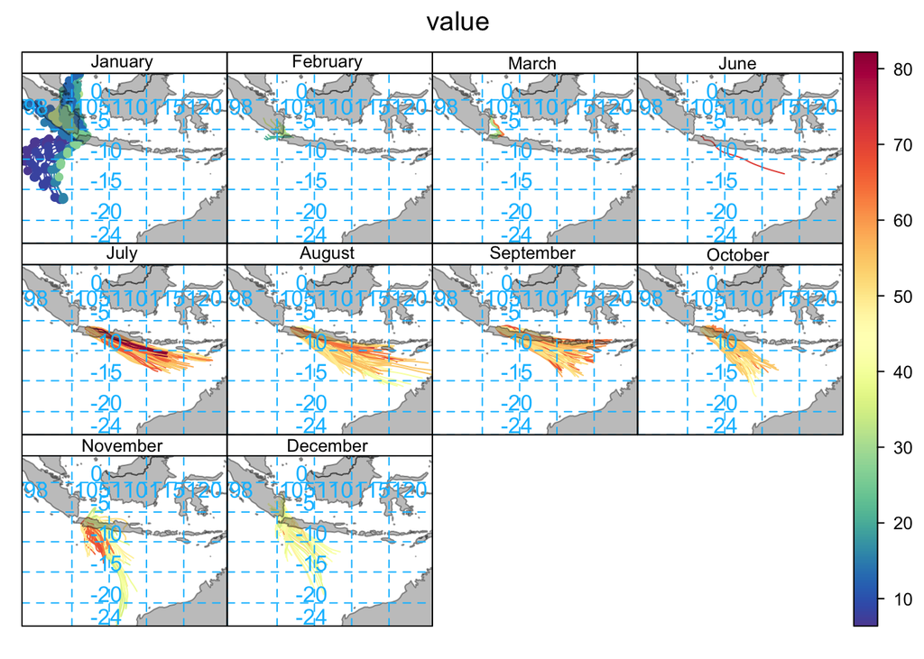

```r
plt.month <- trajPlot(
  trajs.poll.2019,
  pollutant = "value",
  type = "month",
  map = TRUE,
  group = NA,
  map.fill = TRUE,
  map.res = "default",
  map.cols = "grey40",
  map.alpha = 0.4,
  projection = "mercator",
  parameters = NULL,
  orientation = c(90, 0, 0),
  grid.col = "deepskyblue",
  npoints = 12,
  origin = TRUE
)
```

Plotting clusters:

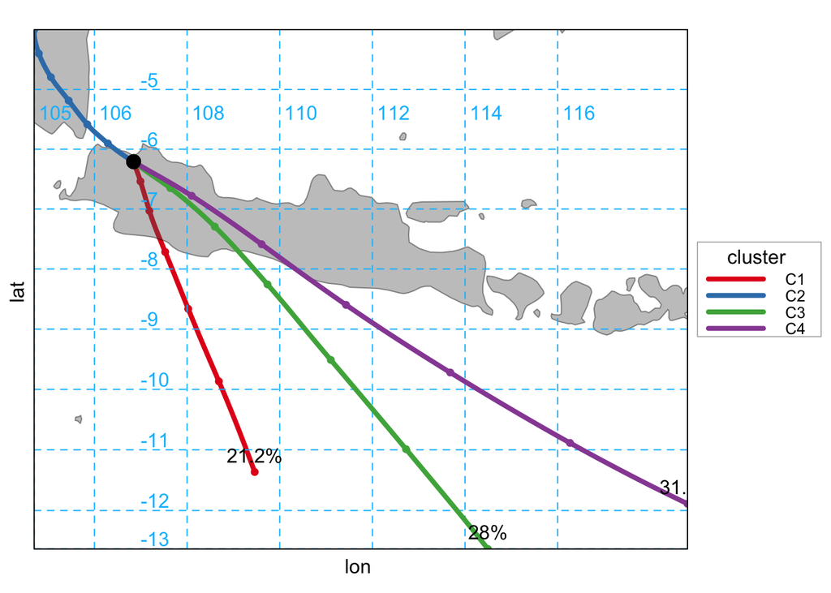

[figure not shown]

```r
plot_traj_clusters <- function(trajs, n_clusters=4, statistics="frequency"){

  openair::trajCluster(
    trajs.2019,
    method = "Euclid",
    n.cluster = n_clusters,
    plot = T,
    type = "default",
    cols = "Set1",
    split.after = FALSE,
    map.fill = TRUE,
    map.cols = "grey40",
    map.alpha = 0.4,
    projection = "mercator",
    parameters = NULL,
    orientation = c(90, 0, 0),
    by.type = FALSE,
    origin = TRUE
  )
}

(plt.trajs.2019 <- plot_traj_clusters(trajs.2019))
```

Many more plotting available [here](https://bookdown.org/david_carslaw/openair/sec-trajPlot.html)

### Combining EDGAR with HYSPLIT